# Git, Github

## 2.4 Clone Courses Repo

Next, you want to clone the repository to your local machine. Note that the URL can be copied from lower right of the repository main page.

[figure not shown]

Now return to the Git Bash shell to clone your courses repository into `H:\github`.

```bash
# change directory to your github container folder
cd ~/github

# clone your courses repository
git clone https://github.com/USER/courses.git

# change directory to inside the newly created courses folder
cd courses

# tell git YOUR user name and email
git config user.name "FIRST LAST"
git config user.email YOURS@BREN.UCSB.EDU

# tel git to cache your password
git config credential.helper wincred

# check git status of the repository
git status

# make a directory for this course
mkdir esm296-4f

# notice the status is the same after creating a directory
# because no content (ie files) have been added yet
git status

# touch a file in our class folder to create content
touch esm296-4f/README.md

# now git notices "untracked files" in the esm296-4f directory
git status

# add this folder (and by default all the files contained therein)
git add esm296-4f

# now git notes "changes to be committed" with a new file
git status

# commit those changes with a message and close issue #1
git commit -m "first commit. closes #1"

# now git says your branch is ahead of 'origin/master' by 1 commit
git status

# go ahead and push those changes
# git will prompt you for your Github username and password and remember it for future
git push
```

Now that you’ve pushed the changes to github, visit your courses repo online and you should see that issue #1 got automatically closed. For more, check out [Mastering Issues](https://guides.github.com/features/issues/).

OK, now you have two way pull and push capability with your Github courses repository. Wouldn’t it be nice though to not have to use the command line every time you add a file?

# 3 RStudio

Entrez RStudio which provides a handy little interface for basic git commands.

## 3.1 Configure RStudio

Launch the RStudio program. First, let’s configure RStudio to play nicely with git. Go to the menu Tools > Global Options…

- Git/SVN > Git executable: Browse… and paste `C:\Program Files (x86)\Git\bin\git.exe`
- R General
  - untick: Restore .Rdata into workspace at startup
  - Save workspace to .RData on exit: Never
- OK, and restart RStudio

## 3.2 Pull esm296-4f Repo

Notice the panes in the upper right: Environment, History. Go to menu File > Open Project… (or in furthest upper right Project: (None) > Open Project…) and navigate to `H:\github\esm296-4f\esm296-4f.Rproj`. This is an RStudio project file that simply points to a folder and retains project specific options. You should now see an extra pane in the upper right: Git.

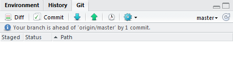

To synchronize the course content on Github with your local H drive, all you need to do is click the blue down arrow. This is equivalent to the following command in the Git Bash shell:

```bash
cd ~/github/esm296-4f
git pull
```

## 3.3 Pull and Push courses Repo

Let’s similarly setup an RStudio project for your courses repo. Go to menu File > New Project… (or in furthest upper right Project: (None) > New Project…) and browse to `H:\github\courses`.

[figure not shown]

In the Files pane (lower right) click on README.md, modify the text (simply adding a return will do) in the editor pane. Save the file. Notice the Git pane in which the newly added file courses.Rproj has a “?” Status indicating it is an “untracked file” like `git status` in the Git Bash previously told us. And now the README.md has a status of “M” for modified.

Now click Commit to get a popup that allows you to tick files or folders (with files inside) to add or confirm modification and enter a commit message (required).

[figure not shown]

# 4 File Structure

So your local file structure will look like this:

H:/

- **github/esm296-4f/** read-only course repo
- **github/courses/esm296-4f/** read-write personal courses repo containing esm296-4f folder
- **esm296-4f/** personal workspace for working through labs and everything else, especially for big data files

# 5 Create Issues

Invite instructors. From your courses repo main page, Settings > Collaborators and invite: `bbest`, `JamesFrew`, `lwedding`.

Quickly create new issues in your courses repo for:

1. lab1
2. lab2
3. lab3
4. lab4
5. lab5
6. project proposal
7. final project

You can direct questions in private towards us by including `@bbest`, `@JamesFrew`, and/or `@lwedding` in any part of a comment to an issue. Or you can create an issue in the [esm296-4f course repository](https://github.com/ucsb-bren/esm296-4f/issues) for all to see.

# 6 More on Git/Github

- try.github.io: git command line tutorial through browser
- [rogerdudler/git-guide](http://rogerdudler.github.io/git-guide): one page simple guide, “no deep shit”
- guides.github.com: more in depth per topic
- [software-carpentry/git](http://www.software-carpentry.org/v5/novice/git): great novice walk through and reference